# act_report

## Étape 5 : analyse et visualisation des données

Étape 1 : Questions  
Étape 2 : Analyse Exploratoire des données  
Étape 3 : Conclusion

1. Le nombre de retweet permet-elle beaucoup de favori ?
2. Est-ce que le nombre d’user_followers augmente le nombre de favori ?
3. Quelle année l'auteur compte le plus de favorite(j'aime) ?
4. Quels sont les cinq premiers chiens ayant reçu le plus de favori (j’aime) durant l'année 2017 ?
5. Le nombre de retweet augmente-t-elle en fonction de l’année ?

```python
# Chargement des librairies necessaire
import pandas as pd
import numpy as np
import matplotlib.pyplot as plt
import seaborn as sns
```

```python
# Chargement du dataset pour l'analyse

twitter_archive_master = pd.read_csv("twitter_archive_master.csv")
dft = twitter_archive_master.copy()
```

```python
dft.info()
```

```
<class 'pandas.core.frame.DataFrame'>
RangeIndex: 1318 entries, 0 to 1317
Data columns (total 26 columns):
 #   Column                 Non-Null Count  Dtype
---  ------                 --------------  -----
 0   tweet_id               1318 non-null   int64
 1   in_reply_to_status_id  15 non-null     float64
 2   in_reply_to_user_id    15 non-null     float64
 3   timestamp              1318 non-null   object
 4   text                   1318 non-null   object
 5   expanded_urls          1318 non-null   object
 6   rating_numerator       1318 non-null   float64
 7   rating_denominator     1318 non-null   float64
 8   name                   937 non-null    object
 9   source_link            1318 non-null   object
```

[output cut: 18 more lines]

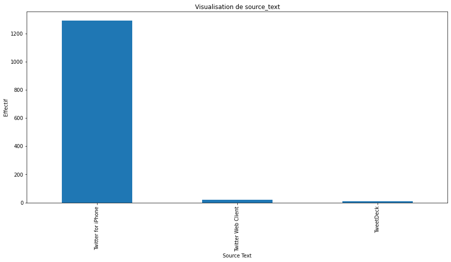

```python
plt.figure(figsize=(15, 7), facecolor="white")
dft.source_text.value_counts().plot(kind="bar")
plt.xlabel("Source Text")
plt.ylabel("Effectif")
plt.title("Visualisation de source_text")
```

#### Interprétation

L'analyse de source_text contient majoritairement twitter for iphone soit 98.05% et en minoritairement Twitter Web Client 1.41% et 0.54% TweetDeck. La représentation ci-dessus nous donne une visuelle sur les différentes proportions.

```python
dft.timestamp = dft.timestamp.astype("datetime64")
```

```python
dft["Year"] = dft.timestamp.dt.year
```

```python
100 * dft.Year.value_counts()/dft.Year.shape[0]
```

```
2016    50.151745
2015    34.066768
2017    15.781487
Name: Year, dtype: float64
```

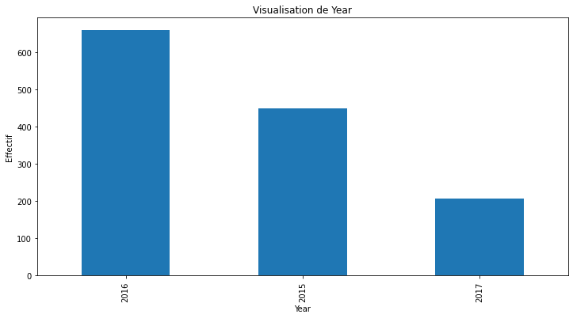

```python
plt.figure(figsize=(12, 6))
dft.Year.value_counts().plot(kind="bar")
plt.title("Visualisation de Year")
plt.ylabel("Effectif")
plt.xlabel("Year")
```